# The price of getting into London

Rail fares to the capital, weighed against the distance and time it takes to get there

Author

Adam Dennett

Published

November 23, 2026

## What this document does

This analysis builds a **station-level data panel of walk-up rail fares into London** from the Rail Delivery Group (RDG/ATOC) national fares feed, joins it to station coordinates, and asks: *relative to how far away a station is — and roughly how long the train takes — where is it cheap or expensive to commute from?*

The motivating observations:

- **Brighton → London** is priced differently by route: the “any permitted” fare (Victoria via the old Southern main line) costs more than the Thameslink-only fare into London Bridge / Blackfriars, for a journey of similar length.
- **Brighton vs Leicester**: both are roughly an hour from a central London terminal, yet the annual season from Leicester to St Pancras costs about twice the Brighton one.

### Data sources

| Source | What it provides | Refresh route |
| --- | --- | --- |
| `RJFAF851` fares feed (this copy generated **25/05/2018**) | Every priced flow, fare and ticket type in GB | Rail Data Marketplace → [**Fares** data product](https://raildata.org.uk/dataProducts) (published by Rail Delivery Group). Download the latest `RJFAFxxx.ZIP`, unzip, and point `params$feed_dir` at it … |
| `UK stations.csv` | Station names, lat/long, CRS (TLC) and NLC codes | Rail Data Marketplace station/location products, or the ORR estimates of station usage file |
| `timetable/May18 Published Archive CIF.gz` | Fastest direct AM-peak journey time to each London terminal (via `R/build_journey_times.R`) | Rail Data Marketplace → **NWR Historical Timetable Data** (May 2018 file matches this fares feed; May/Dec editions 2016–2025 available) or the RDG **Timetable – Full Refresh** products for current dat… |
| `SP0035.pdf` | The record layout specification used for the parsers below | — |

**Fares shown are from May 2018.** Relative differences between flows are remarkably persistent over time (regulated fares all move by the same cap), so the *value* conclusions are more durable than the price levels. To bring the whole panel up to date, drop in a current feed from the Marketplace.

### How fares to “London” work in the feed

1. **London Terminals.** Most fares are priced to the pseudo-location `1072 LONDON TERMINALS`, not to a specific terminus. Each terminal’s location record carries `fare_group = 1072`, which is how we find them all. Some flows *are* priced to a specific terminal (e.g. Brighton → Victoria `5426`, Brighton → Blackfriars `5112`) — these are what create the route-level price differences.
2. **Clusters.** Many fares are priced between *station clusters* (`.FSC` file), so a station inherits fares set for any cluster it belongs to, and likewise for its fare group.
3. **Seasons.** The feed holds a 7-day season (`7DS`). Longer seasons are derived by the industry formula **monthly = 3.84 × weekly-basis, annual = 40 × weekly-basis**, where the basis is the `PSS` (season standard) fare if one exists, otherwise the `7DS` fare. (Leicester is a live example: walk-up weekly `7DS` = £270.00 but the annual is 40 × `PSS` £233.00 ≈ £9,320 — matching the published annual season.)
4. **The zone-priced belt.** Stations on the Thameslink Bedford line (Harpenden, Luton, St Albans, Flitwick…) have their walk-up London fares priced not to 1072 but to zonal pseudo-destinations — `LONDON ZONES 1-6` and friends — as **Travelcards** (`ADT`/`ODT`/`AM3`/`WRE` day tickets, `7TS` weekly season). These are included and mapped to the matching categories; note a Travelcard also covers Tube and bus in the zones, so these stations get slightly *more* product for the money than terminal-only fares elsewhere.

```r
library(data.table)
library(ggplot2)
library(ggrepel)
library(geodist)
library(DT)
library(leaflet)

# ---- Basemap, no API key ---------------------------------------------
# CARTO require a key on their raster tiles, and without one the tiles
# carry an "API key required" watermark. That failed in the only way
# that really matters: silently. Any render from a shell without
# CARTO_KEY in its environment produced watermarked maps and no other
# symptom, so the fault was found by eye or not at all.
#
# So the tiles come from Esri's World Gray Canvas instead, which needs
# no key. Of the keyless alternatives it is the one that actually is
# keyless: Stadia's tiles return 401 without a key and Jawg's return
# 400, both having moved to requiring one.
#
# This still wraps addProviderTiles() so that no call site has to
# change. A CartoDB.* provider is served from Esri; anything else is
# passed straight through to leaflet. Esri splits the canvas and the
# place names into two services where CARTO bakes them into one, so the
# Positron-style variants map onto one or both of them, and the
# DarkMatter ones onto Esri's dark canvas.
#
# maxNativeZoom is set because Esri publishes these canvases to zoom 16
# and above that the server returns a grey tile reading "Map data not
# yet available" rather than a 404 - a silent failure again. Leaflet
# upsamples level 16 instead of asking for 17, so the basemap softens
# past that point and the data drawn over it stays sharp.
addProviderTiles <- function(map, provider, ...) {
  nm <- as.character(provider)[1]
  if (!startsWith(nm, "CartoDB."))
    return(leaflet::addProviderTiles(map, provider, ...))
  nm <- substring(nm, 9L)

  dark <- startsWith(nm, "DarkMatter")
  shade <- if (dark) "Dark" else "Light"
  esri <- function(part) sprintf(paste0(
    "https://server.arcgisonline.com/ArcGIS/rest/services/Canvas/",
    "World_%s_Gray_%s/MapServer/tile/{z}/{y}/{x}"), shade, part)

  want_base   <- !grepl("OnlyLabels$", nm)
  want_labels <- !grepl("NoLabels$", nm)

  dots <- list(...)
  opts <- leaflet::tileOptions(maxNativeZoom = 16, maxZoom = 20)
  if (!is.null(dots$options)) {
    opts <- utils::modifyList(opts, dots$options); dots$options <- NULL
  }
  attrib <- paste0(
    'Tiles &copy; <a href="https://www.esri.com/">Esri</a> &mdash; Esri, ',
    'HERE, Garmin, &copy; ',
    '<a href="https://www.openstreetmap.org/copyright">OpenStreetMap</a>',
    ' contributors')

  if (want_base)
    map <- do.call(leaflet::addTiles, c(list(
      map, urlTemplate = esri("Base"), attribution = attrib,
      options = opts), dots))
  # Only one of the two layers carries the credit, or every map would
  # print it twice in the corner.
  if (want_labels)
    map <- do.call(leaflet::addTiles, c(list(
      map, urlTemplate = esri("Reference"),
      attribution = if (want_base) "" else attrib,
      options = opts), dots))
  map
}
# ----------------------------------------------------------------------
library(plotly)
library(crosstalk)

# interactive scatter with a station search box: wraps a ggplot built on a
# crosstalk SharedData so plotly's selectize search can highlight stations
searchable <- function(g, height = NULL) {
  ggplotly(g, tooltip = "text", height = height) |>
    highlight(on = "plotly_click", off = "plotly_doubleclick",
              selectize = TRUE, persistent = FALSE, color = "red")
}
library(knitr)
library(kableExtra)
library(scales)

feed_dir  <- params$feed_dir
feed_stem <- file.path(feed_dir, basename(feed_dir))   # e.g. .../RJFAF851/RJFAF851
stopifnot(file.exists(paste0(feed_stem, ".FFL")))

cache_dir <- file.path(dirname(feed_dir), "cache")
dir.create(cache_dir, showWarnings = FALSE)

# cache expensive parses keyed on feed version, so re-renders are fast and a
# new feed automatically invalidates the cache
cached <- function(name, expr) {
  f <- file.path(cache_dir, paste0(basename(feed_dir), "_", name, ".rds"))
  if (file.exists(f)) return(readRDS(f))
  x <- eval.parent(substitute(expr))
  saveRDS(x, f)
  x
}

ddmmyyyy <- function(s) as.IDate(s, format = "%d%m%Y")
fmin <- function(x) if (all(is.na(x))) NA_real_ else min(x, na.rm = TRUE)

# read a fixed-width feed file as raw lines, dropping /!! header comments
read_feed <- function(ext) {
  x <- fread(paste0(feed_stem, ".", ext), sep = NULL, header = FALSE,
             col.names = "line", quote = "", strip.white = FALSE)
  x[!startsWith(line, "/")]
}

# the feed's own generation date defines "today" for validity filtering
dat_hdr <- readLines(paste0(feed_stem, ".DAT"), n = 6, warn = FALSE)
as_of   <- as.IDate(sub(".*Generated:\\s+(\\d{2}/\\d{2}/\\d{4}).*", "\\1",
                        grep("Generated", dat_hdr, value = TRUE)[1]),
                    format = "%d/%m/%Y")
current <- function(dt) dt[start <= as_of & end >= as_of]
```

Feed **RJFAF851**, priced as at **25 May 2018**.

## Building the data panel

### Locations, London terminals, clusters

```r
loc <- cached("loc", {
  x <- read_feed("LOC")[startsWith(line, "RL")]
  x <- x[, .(end   = ddmmyyyy(substr(line, 10, 17)),
             start = ddmmyyyy(substr(line, 18, 25)),
             nlc   = substr(line, 37, 40),
             name  = trimws(substr(line, 41, 56)),
             crs   = trimws(substr(line, 57, 59)),
             fare_group = substr(line, 70, 73))]
  unique(current(x), by = "nlc")
})

# the terminals group PLUS the zonal pseudo-destinations that include zone 1
# ("LONDON ZONES 1-x"): the Thameslink belt (Harpenden, Luton, St Albans,
# Flitwick...) has its London fares priced to these as Travelcards, not to 1072
london_nlc <- union(loc[fare_group == "1072" | nlc == "1072", nlc],
                    loc[grepl("^LONDON ZONES 1", name), nlc])

fsc <- cached("fsc", {
  x <- read_feed("FSC")
  current(x[, .(cluster = substr(line, 2, 5), member = substr(line, 6, 9),
                end   = ddmmyyyy(substr(line, 10, 17)),
                start = ddmmyyyy(substr(line, 18, 25)))])
})

london_clusters <- fsc[member %chin% london_nlc, unique(cluster)]
london_codes    <- union(london_nlc, london_clusters)

loc[nlc %chin% london_nlc, .(nlc, name, crs)] |>
  kable(caption = "Locations in the London Terminals fare group (1072)") |>
  kable_styling(full_width = FALSE)
```

Locations in the London Terminals fare group (1072)

| nlc | name | crs |
| --- | --- | --- |
| 0032 | LONDON ZONES 1-2 |  |
| 0033 | LONDON ZONES 1-3 |  |
| 0034 | LONDON ZONES 1-4 |  |
| 0035 | LONDON ZONES 1-6 |  |
| 0064 | LONDON ZONES 1-5 |  |
| 1072 | LONDON TERMINALS |  |
| 1444 | LONDON EUSTON | EUS |
| 1475 | LONDON MARYLEBNE | MYB |
| 1555 | LONDON ST PANCRS | STP |
| 3087 | LONDON PADDINGTN | PAD |
| 5112 | LONDON BLKFRIARS | BFR |
| 5121 | CITY THAMESLINK | CTK |
| 5142 | LONDON CANNON ST | CST |
| 5143 | LONDON CHARING X | CHX |
| 5148 | LONDON BRIDGE | LBG |
| 5158 | LONDON WATRLOO E | WAE |
| 5426 | LONDON VICTORIA | VIC |
| 5597 | VAUXHALL | VXH |
| 5598 | LONDON WATERLOO | WAT |
| 6003 | OLD STREET | OLD |
| 6005 | MOORGATE | MOG |
| 6121 | LONDON KINGS X | KGX |
| 6965 | LONDON LIVRPL ST | LST |
| 7490 | LONDON FENCH ST | FST |

### Flows and fares into London

The `.FFL` file holds flow records (`RF`: origin, destination, route, validity) and fare records (`RT`: ticket code + price in pence). We keep every flow whose destination is a London code, plus **reversible** (`direction = R`) flows from a London code. One-directional flows *out of* London are deliberately excluded: contra-peak fares can be genuinely cheaper (a London→Brighton anytime day return was £26.20 against £41.90 towards London), so including them would understate commuter-direction prices.

```r
london_fares_raw <- cached("london_fares", {
  ffl <- read_feed("FFL")

  rf <- ffl[startsWith(line, "RF")]
  rf <- current(rf[, .(orig  = substr(line, 3, 6),  dest  = substr(line, 7, 10),
                       route = substr(line, 11, 15), direction = substr(line, 20, 20),
                       end   = ddmmyyyy(substr(line, 21, 28)),
                       start = ddmmyyyy(substr(line, 29, 36)),
                       toc   = substr(line, 37, 39), flow_id = substr(line, 43, 49))])

  rt <- ffl[startsWith(line, "RT")]
  rt <- rt[, .(flow_id = substr(line, 3, 9), ticket = substr(line, 10, 12),
               fare = as.integer(substr(line, 13, 20)),
               restriction = substr(line, 21, 22))]
  rm(ffl); gc(verbose = FALSE)

  inbound  <- rf[dest %chin% london_codes]
  outbound <- rf[orig %chin% london_codes & direction == "R"]
  setnames(outbound, c("orig", "dest"), c("dest", "orig"))
  flows <- rbind(inbound, outbound)

  merge(flows, rt, by = "flow_id", allow.cartesian = TRUE)[
    , .(orig, dest, route, toc, ticket, fare, restriction, source = "FFL")]
})
```

### Non-derivable fare overrides

The `.NFO` file supplies fares that either aren’t in the flow file or override it (spec §6.3–6.4). We take adult, no-railcard records that are current and flagged usable (`composite = "Y"`), and let them **override** matching flow-file fares; suppressed records delete the flow-file fare.

```r
london_fares <- cached("london_fares_nfo", {
  nfo <- read_feed("NFO")
  nfo <- nfo[, .(orig = substr(line, 2, 5),   dest  = substr(line, 6, 9),
                 route = substr(line, 10, 14), railcard = substr(line, 15, 17),
                 ticket = substr(line, 18, 20),
                 end   = ddmmyyyy(substr(line, 22, 29)),
                 start = ddmmyyyy(substr(line, 30, 37)),
                 suppress = substr(line, 46, 46),
                 fare = as.integer(substr(line, 47, 54)),
                 composite = substr(line, 65, 65))]
  # NFO records are directional: keep only fares priced INTO London
  nfo <- current(nfo)[railcard == "   " & dest %chin% london_codes]

  suppressed <- nfo[suppress == "Y", .(orig, dest, route, ticket)]
  additions  <- nfo[suppress != "Y" & composite == "Y" & fare != 99999999L,
                    .(fare = min(fare)), by = .(orig, dest, route, ticket)][
                    , `:=`(toc = "NFO", restriction = "", source = "NFO")]

  out <- london_fares_raw
  if (nrow(suppressed))
    out <- out[!suppressed, on = c("orig", "dest", "route", "ticket")]
  # NFO overrides FFL on the same key
  out <- out[!additions, on = c("orig", "dest", "route", "ticket")]
  rbind(out, additions, fill = TRUE)
})
```

### Ticket types, routes, and the fare categories we care about

```r
tty <- cached("tty", {
  x <- read_feed("TTY")
  x <- x[, .(ticket = substr(line, 2, 4),
             end   = ddmmyyyy(substr(line, 5, 12)),
             start = ddmmyyyy(substr(line, 13, 20)),
             tkt_desc = trimws(substr(line, 29, 43)),
             class = substr(line, 44, 44), type = substr(line, 45, 45))]
  unique(current(x), by = "ticket")
})

rte <- cached("rte", {
  x <- read_feed("RTE")[startsWith(line, "RR")]
  x <- x[, .(route = substr(line, 3, 7),
             end   = ddmmyyyy(substr(line, 8, 15)),
             start = ddmmyyyy(substr(line, 16, 23)),
             route_desc = trimws(substr(line, 32, 47)))]
  unique(current(x), by = "route")
})

# the standard-class walk-up ticket codes used nationally, plus the
# Travelcard codes used on the zone-priced flows (ADT/ODT/AM3/WRE day
# Travelcards, 7TS weekly Travelcard season)
categories <- data.table(
  ticket   = c("SDS","SDR","SOS","SOR","CDS","CDR","SVS","SVR","SSS","SSR","7DS","PSS",
               "ADT","ODT","AM3","WRE","7TS"),
  category = c("anytime_day_single","anytime_day_return",
               "anytime_single","anytime_return",
               "offpeak_day_single","offpeak_day_return",
               "offpeak_single","offpeak_return",
               "super_offpeak_single","super_offpeak_return",
               "weekly_season","season_basis",
               "anytime_day_return","offpeak_day_return",
               "super_offpeak_return","super_offpeak_return","weekly_season"))

fares_cat <- merge(london_fares, categories, by = "ticket")
fares_cat <- merge(fares_cat, rte[, .(route, route_desc)], by = "route", all.x = TRUE)
```

### From fare codes to stations

A station can buy any fare priced against (a) its own NLC, (b) its fare group, or (c) any cluster containing either. We expand those memberships, then take the **cheapest fare per station × category**, remembering which route and London destination achieved it.

```r
stations <- loc[crs != "" & !nlc %chin% london_nlc & fare_group != "1072",
                .(nlc, name, crs, fare_group)]

# every code through which a station can inherit a fare
memb <- rbind(
  stations[, .(nlc, code = nlc)],
  stations[fare_group != nlc, .(nlc, code = fare_group)],
  merge(stations[, .(nlc, member = nlc)], fsc[, .(member, cluster)],
        by = "member")[, .(nlc, code = cluster)],
  merge(stations[, .(nlc, member = fare_group)], fsc[, .(member, cluster)],
        by = "member")[, .(nlc, code = cluster)]
) |> unique()

sf_long <- merge(memb, fares_cat, by.x = "code", by.y = "orig",
                 allow.cartesian = TRUE)
sf_long <- merge(sf_long, loc[, .(nlc, dest_name = name)],
                 by.x = "dest", by.y = "nlc", all.x = TRUE)

# cheapest record per station x category (+ route detail retained separately)
setorder(sf_long, fare)
best <- sf_long[, .SD[1], by = .(nlc, category),
                .SDcols = c("fare", "route", "route_desc", "dest", "dest_name")]

panel <- dcast(best, nlc ~ category, value.var = "fare")
num_cols <- setdiff(names(panel), "nlc")
panel[, (num_cols) := lapply(.SD, function(x) x / 100), .SDcols = num_cols]

# headline fares -------------------------------------------------------------
# peak     = best fully-flexible return (anytime day return or anytime return)
# off-peak = best restricted walk-up return (off-peak / super off-peak)
panel[, peak_return    := pmin(anytime_day_return, anytime_return, na.rm = TRUE)]
panel[, offpeak_return := pmin(offpeak_day_return, offpeak_return,
                               super_offpeak_return, na.rm = TRUE)]
panel[, peak_single    := pmin(anytime_day_single, anytime_single, na.rm = TRUE)]
panel[, offpeak_single := pmin(offpeak_day_single, offpeak_single,
                               super_offpeak_single, na.rm = TRUE)]
# annual season: 40 x the season basis (PSS if present, else the 7-day price)
panel[, annual_season  := 40 * fifelse(!is.na(season_basis), season_basis, weekly_season)]

# which route/terminal delivers the cheapest season
season_route <- best[category %in% c("season_basis", "weekly_season")]
setorder(season_route, fare)
season_route <- season_route[, .SD[1], by = nlc,
                             .SDcols = c("route_desc", "dest_name")]
panel <- merge(panel, season_route, by = "nlc", all.x = TRUE)

panel <- merge(stations[, .(nlc, station = name, crs)], panel, by = "nlc")
```

### Geography: coordinates, distance, and (estimated) journey time

```r
uks <- fread(params$stations_csv)
uks <- uks[, .(station_name = Station, lat = Latitude, lon = Longitude,
               crs = TLC, nlc_csv = sprintf("%04d", as.integer(NLC)))]

panel <- merge(panel, unique(uks[, .(nlc_csv, lat, lon)]),
               by.x = "nlc", by.y = "nlc_csv", all.x = TRUE)
crs_fill <- unique(uks[!is.na(lat)], by = "crs")
panel[crs_fill, on = "crs",
      c("lat", "lon") := .(fcoalesce(lat, i.lat), fcoalesce(lon, i.lon))]

geo_matched <- panel[!is.na(lat), .N]

# straight-line distance to Charing Cross (the traditional London datum),
# with a 1.2 circuity factor to approximate route km
chx <- c(lon = -0.1247, lat = 51.5073)
panel[!is.na(lat),
      dist_km := as.numeric(geodist(cbind(lon, lat), t(chx),
                                    measure = "haversine")) / 1000]
panel[, rail_km := dist_km * 1.2]

# ---- journey time -----------------------------------------------------------
# If data/journey_times.csv exists (columns: crs, minutes) it is used.
# Otherwise we ESTIMATE time from distance: average speed rises with distance
# (stopping services near London, intercity further out). This is a placeholder
# to make the value analysis runnable end-to-end - see the appendix for how to
# replace it with real timetable times from the Rail Data Marketplace.
jt_file <- file.path(dirname(feed_dir), "data", "journey_times.csv")
panel[, est_speed_kmh := pmin(150, 50 + 0.5 * dist_km)]
panel[, time_min := rail_km / est_speed_kmh * 60]
panel[, `:=`(time_source = "estimated", time_terminal = NA_character_)]
if (file.exists(jt_file)) {
  jt <- fread(jt_file)
  if (!"terminal" %in% names(jt)) jt[, terminal := NA_character_]
  panel[jt, on = "crs", `:=`(time_min = i.minutes, time_source = "timetable",
                             time_terminal = i.terminal)]
}
```

Coordinates matched for **2527 of 2605** stations with London fares. Journey times are **timetable-based where supplied, estimated elsewhere** — treat time-based results as indicative until real timetable times are dropped in.

### The finished panel

One row per GB station: peak/off-peak walk-up fares, weekly and annual seasons, the route that achieves the cheapest season, distance and journey time. Saved alongside this document as `data/london_fare_panel.csv`.

```r
setorder(panel, station)
dir.create(file.path(dirname(feed_dir), "data"), showWarnings = FALSE)
fwrite(panel, file.path(dirname(feed_dir), "data", "london_fare_panel.csv"))

panel[!is.na(annual_season) & !is.na(dist_km),
      .(Station = station, CRS = crs,
        `Peak rtn` = peak_return, `Off-peak rtn` = offpeak_return,
        `Weekly` = weekly_season, `Annual` = annual_season,
        `Via` = route_desc, `To` = dest_name,
        `Km` = round(dist_km), `Est mins` = round(time_min))] |>
  datatable(rownames = FALSE, filter = "top",
            options = list(pageLength = 10, scrollX = TRUE)) |>
  formatCurrency(c("Peak rtn", "Off-peak rtn", "Weekly", "Annual"),
                 currency = "£", digits = 2)
```

| Station | CRS | Peak rtn | Off-peak rtn | Weekly | Annual | Via | To | Km | Est mins |
| --- | --- | --- | --- | --- | --- | --- | --- | --- | --- |
| ABBEY WOOD | ABW | 9.1 |  | 35 | 1400 | ANY PERMITTED | LONDON TERMINALS | 17 | 27 |
| ABER | ABE | 234.2 | 78.8 | 348.3 | 12872 | ANY PERMITTED | LONDON TERMINALS | 215 | 103 |
| ABERCYNON | ACY | 234.2 | 78.8 | 348.3 | 12872 | ANY PERMITTED | LONDON TERMINALS | 222 | 107 |
| ABERDARE | ABA | 234.2 | 78.8 | 348.3 | 12872 | ANY PERMITTED | LONDON TERMINALS | 231 | 111 |
| ABERGAVENNY | AGV | 98 | 64.3 | 251.2 | 11856 | WARMSTER-SALSBRY | LONDON TERMINALS | 202 | 97 |
| ACCRINGTON | ACR | 352 | 92.9 |  | 16968 | ANY PERMITTED | LONDON TERMINALS | 292 | 140 |
| ACKLINGTON | ACK | 308 | 140.8 |  | 20320 | ANY PERMITTED | LONDON TERMINALS | 435 | 209 |
| ACLE | ACL | 113.6 | 56.4 | 204.4 | 8176 | ANY PERMITTED | LONDON TERMINALS | 170 | 91 |
| ACOCKS GREEN | ACG | 82 | 29.5 | 144 | 8380 | WMR &amp; LNR ONLY | LONDON EUSTON | 156 | 88 |
| ACTON BRIDGE | ACB | 110 | 41 | 201 | 11804 | WMR &amp; LNR ONLY | LONDON EUSTON | 258 | 124 |

[output cut: 1938 more lines]

## Analysis

```r
an <- panel[!is.na(annual_season) & !is.na(dist_km) & dist_km >= params$min_km]
an[, `:=`(annual_per_km   = annual_season / rail_km,
          annual_per_day  = annual_season / params$commuting_days,
          pence_per_min   = annual_season / (2 * params$commuting_days) / time_min * 100)]

highlight <- c("BRIGHTON", "LEICESTER", "READING", "CAMBRIDGE", "OXFORD",
               "WOKING", "MILTON KEYNES C", "CHELMSFORD", "SEVENOAKS",
               "PETERBOROUGH", "SWINDON", "GRANTHAM", "COLCHESTER",
               "TUNBRIDGE WELLS", "BASINGSTOKE", "BEDFORD", "LUTON")
```

### Fares rise with distance — but on very different lines

Each point is a station’s cheapest annual season against its distance from central London. The vertical spread at any given distance is the interesting part: at ~60 km the annual season ranges over thousands of pounds depending on which line you happen to live on.

```r
d1 <- an[dist_km <= 200]
d1[, txt := sprintf("%s<br>£%s pa | %.0f km | %.0f min (%s)<br>cheapest via %s",
                    station, comma(annual_season), dist_km, time_min,
                    time_source, route_desc)]
sd1 <- highlight_key(d1, ~station, group = "Fare vs distance — search stations")
g1 <- ggplot(sd1, aes(dist_km, annual_season, text = txt)) +
  geom_point(alpha = 0.45, colour = "#4472a8", size = 1.4) +
  geom_smooth(aes(group = 1), method = "loess", se = FALSE,
              colour = "grey35", linewidth = 0.7) +
  scale_y_continuous(labels = label_currency(prefix = "£")) +
  labs(x = "Straight-line distance from central London (km)",
       y = "Annual season (cheapest route)") +
  theme_minimal()
searchable(g1)
```

[interactive chart not shown]

Annual season cost vs straight-line distance from central London (stations ≥ 15 km, ≤ 200 km). Type in the search box to find and highlight a station; hover any point for detail.

### Cost per kilometre: the commuter-belt premium map

```r
mp <- an[!is.na(lat) & dist_km <= 250]
mp[, ppk_pctile := frank(annual_per_km) / .N * 100]
pal <- colorNumeric("RdYlBu", c(0, 100), reverse = TRUE)
leaflet(mp) |>
  addProviderTiles(providers$CartoDB.Positron) |>
  addCircleMarkers(~lon, ~lat, radius = 5, stroke = FALSE, fillOpacity = 0.85,
                   fillColor = ~pal(ppk_pctile),
                   label = ~sprintf("%s — annual £%s, %.0f km, £%.2f/km",
                                    station, comma(annual_season),
                                    dist_km, annual_per_km / 100)) |>
  addLegend("bottomright", pal = pal, values = ~ppk_pctile,
            title = "£/km percentile")
```

[interactive chart not shown]

Annual season pence-per-route-km. Blue = cheap for the distance, red = expensive.

### Which stations are priced above or below the trend?

A simple model — `log(annual season) ~ log(distance)` — captures the broad distance gradient. The **residual** is then a clean measure of whether a station is expensive or cheap *for how far out it is*. (Once real journey times are loaded, refit against time for the sharper question.)

```r
m <- lm(log(annual_season) ~ log(dist_km), data = an)
an[, premium_pct := (exp(residuals(m)) - 1) * 100]

bind_tbl <- function(dt, cap) {
  dt[, .(Station = station, `Annual` = comma(annual_season, prefix = "£"),
         `Km` = round(dist_km),
         `Premium vs trend` = sprintf("%+.0f%%", premium_pct),
         `Cheapest via` = route_desc)] |>
    kable(caption = cap) |> kable_styling(full_width = FALSE)
}
setorder(an, premium_pct)
bind_tbl(head(an[dist_km <= 250], 15), "Best value: cheapest for their distance")
```

Best value: cheapest for their distance

| Station | Annual | Km | Premium vs trend | Cheapest via |
| --- | --- | --- | --- | --- |
| CATERHAM | £1,220 | 25 | -40% | ANY - PERMITTED |
| TADWORTH | £1,220 | 25 | -40% | ANY - PERMITTED |
| KINGSWOOD | £1,220 | 24 | -39% | ANY - PERMITTED |
| BELMONT | £1,012 | 19 | -37% | ANY - PERMITTED |
| TATTENHAM CORNER | £1,220 | 24 | -37% | ANY - PERMITTED |
| MALDEN MANOR | £932 | 17 | -36% | ANY - PERMITTED |
| WHYTELEAFE SOUTH | £1,220 | 23 | -36% | ANY - PERMITTED |
| WORCESTER PARK | £932 | 16 | -35% | ANY - PERMITTED |
| CHEAM | £1,012 | 18 | -35% | ANY - PERMITTED |
| UPPER WARLINGHAM | £1,220 | 22 | -34% | ANY - PERMITTED |
| CHIPSTEAD | £1,220 | 22 | -34% | ANY - PERMITTED |
| WHYTELEAFE | £1,220 | 22 | -34% | ANY - PERMITTED |
| EPSOM DOWNS | £1,220 | 22 | -33% | ANY - PERMITTED |
| TEMPLECOMBE | £6,536 | 169 | -33% | ANY PERMITTED |
| KENTON | £932 | 16 | -33% | CLAPHAM JUNCTION |

```r
bind_tbl(tail(an[dist_km <= 250], 15)[order(-premium_pct)],
         "Worst value: most expensive for their distance")
```

Worst value: most expensive for their distance

| Station | Annual | Km | Premium vs trend | Cheapest via |
| --- | --- | --- | --- | --- |
| EBBSFLEET INT SE | £4,668 | 32 | +89% | PLUS HIGH SPEED |
| RADLETT | £3,348 | 24 | +71% | ANY - PERMITTED |
| HARPENDEN | £4,672 | 38 | +64% | ANY - PERMITTED |
| LUTON AIRPORT PW | £5,216 | 45 | +59% | ANY - PERMITTED |
| LUTON | £5,256 | 46 | +56% | ANY - PERMITTED |
| ST ALBANS CITY | £3,712 | 30 | +55% | AAA ST ALBNS ABY |
| WATFORD JUNCTION | £3,108 | 26 | +50% | ANY PERMITTED |
| ASCOT (BERKS) | £4,464 | 40 | +50% | VIA STAINES |
| WATFORD NORTH | £3,152 | 26 | +49% | ANY PERMITTED |
| GARSTON (HERTS) | £3,152 | 27 | +47% | ANY PERMITTED |
| LEAGRAVE | £5,256 | 50 | +47% | ANY - PERMITTED |
| OTFORD | £3,500 | 31 | +44% | NOT VALID ON HS1 |
| BRICKET WOOD | £3,152 | 27 | +44% | ANY PERMITTED |
| FARNINGHAM ROAD | £3,132 | 28 | +42% | NOT VALID ON HS1 |
| HOW WOOD | £3,152 | 28 | +42% | ANY PERMITTED |

### Weighing money against time

A season ticket buys access to London; time on the train is also a cost. *Generalised cost* is the standard transport-appraisal way (HM Treasury Green Book / DfT’s TAG guidance) of putting the two on one scale: convert travel time into money at a “value of time” and add it to the fare. In plain terms: take the annual season ticket, then add what a year’s worth of sitting on the train is worth — **2** journeys a day (out and back), times 230 commuting days a year, times the journey length in hours, times **£13.1 per hour** (the DfT’s appraisal value for commuters’ time, which you can and should vary to taste — the “Price or speed?” comparison further down shows how the rankings move when you do):

$$\text{generalised cost} = \text{annual season} + \underbrace{2 \times \text{days} \times \tfrac{\text{minutes}}{60} \times \text{VoT}}_{\text{a year of train time, in £}}$$

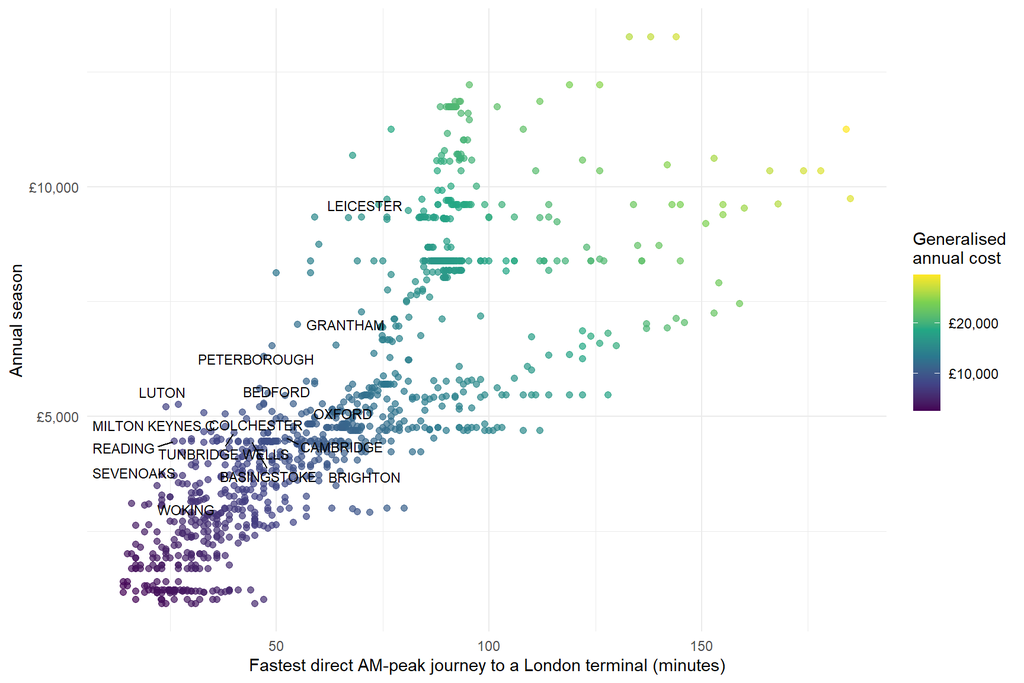

Generalised annual commuting cost (fare + time valued at £13.10/hr). Timetable journey times where available, distance-based estimates otherwise.

```r
an[, gen_cost := annual_season +
     2 * params$commuting_days * (time_min / 60) * params$vot_per_hour]

ggplot(an[dist_km <= 200], aes(time_min, annual_season)) +
  geom_point(aes(colour = gen_cost), alpha = 0.7, size = 1.8) +
  scale_colour_viridis_c(labels = label_currency(prefix = "£"),
                         name = "Generalised\nannual cost") +
  geom_text_repel(data = an[station %in% highlight & dist_km <= 200],
                  aes(label = station), size = 3, max.overlaps = 20) +
  scale_y_continuous(labels = label_currency(prefix = "£")) +
  labs(x = "Fastest direct AM-peak journey to a London terminal (minutes)",
       y = "Annual season") +
  theme_minimal()
```

```r
setorder(an, gen_cost)
an[dist_km <= 200][1:15,
   .(Station = station, `Annual` = comma(annual_season, prefix = "£"),
     `Est mins` = round(time_min),
     `Generalised cost` = comma(round(gen_cost), prefix = "£"))] |>
  kable(caption = "Lowest generalised annual commuting cost (≤ 200 km)") |>
  kable_styling(full_width = FALSE)
```

Lowest generalised annual commuting cost (≤ 200 km)

| Station | Annual | Est mins | Generalised cost |
| --- | --- | --- | --- |
| HARROW & WLDSTNE | £1,168 | 14 | £2,574 |
| SOUTH CROYDON | £1,012 | 17 | £2,719 |
| SOUTHALL | £1,320 | 14 | £2,726 |
| NEW ELTHAM | £1,400 | 14 | £2,806 |
| SUDBURY HILL | £1,320 | 15 | £2,826 |
| SURBITON | £1,196 | 17 | £2,903 |
| ELMSTEAD WOODS | £1,400 | 15 | £2,906 |
| TWICKENHAM | £1,168 | 19 | £3,076 |
| SEVEN KINGS | £1,320 | 19 | £3,228 |
| SANDERSTEAD | £1,220 | 20 | £3,229 |
| WORCESTER PARK | £932 | 23 | £3,242 |
| GREENFORD | £1,320 | 20 | £3,294 |
| NORTHOLT PARK | £1,692 | 16 | £3,299 |
| BELMONT | £1,012 | 23 | £3,312 |
| WADDON | £1,012 | 23 | £3,322 |

Generalised annual commuting cost (fare + time valued at £13.10/hr). Timetable journey times where available, distance-based estimates otherwise.

## Time, distance and money together

Everything below uses the **real May 2018 timetable times** — the fastest direct train arriving at a London terminal between 06:30 and 10:30 — so it is restricted to stations with a direct AM-peak service.

```r
tt <- an[time_source == "timetable" & !is.na(time_min) & time_min > 0]
tt[, speed_kmh := dist_km / (time_min / 60)]     # straight-line speed
top_term <- tt[, .N, by = time_terminal][order(-N)][1:8, time_terminal]
tt[, term_grp := fifelse(time_terminal %chin% top_term, time_terminal, "Other")]
```

That leaves **726** stations. `speed_kmh` here is *straight-line* speed (distance as the crow flies over timetable minutes), so it understates track speed but is perfectly comparable between stations.

### First, time: who gets fast trains?

Distance buys speed: stopping services dominate close to London, intercity expresses further out. The diagonal guides are straight-line speeds — stations sitting below the 100 km/h line get genuinely quick trains for their distance.

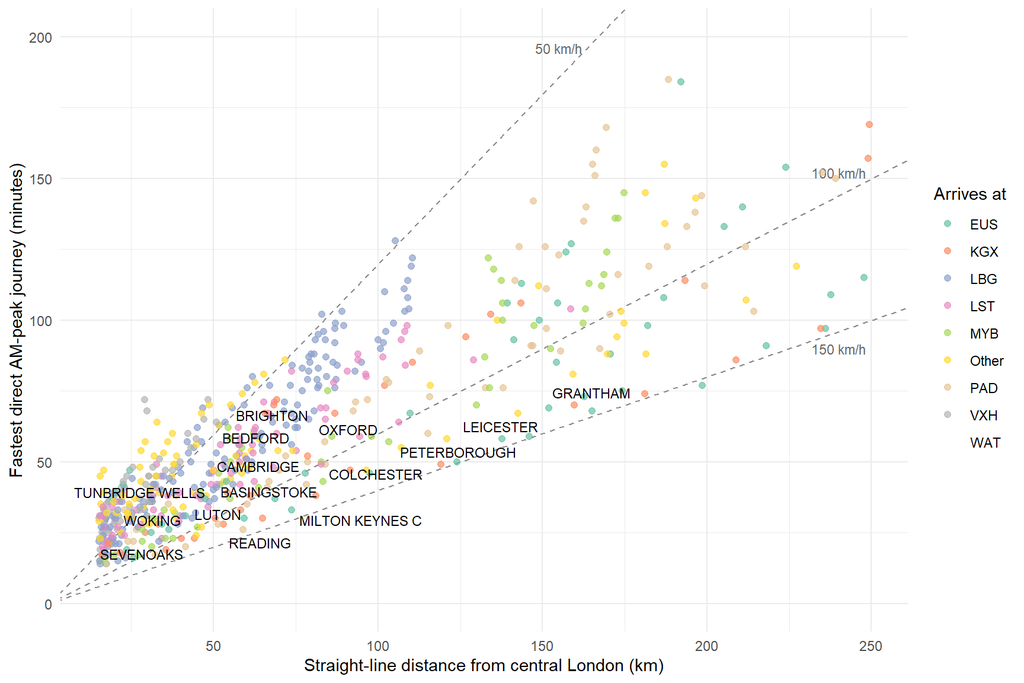

Fastest direct AM-peak journey time vs distance, by arrival terminal. Guide lines show straight-line average speed.

```r
guides_v <- data.table(v = c(50, 100, 150))
ggplot(tt[dist_km <= 250], aes(dist_km, time_min)) +
  geom_abline(data = guides_v, aes(slope = 60 / v, intercept = 0),
              linetype = "dashed", colour = "grey55") +
  annotate("text", x = c(155, 240, 240), y = c(196, 152, 90),
           label = paste(c(50, 100, 150), "km/h"), colour = "grey40", size = 3) +
  geom_point(aes(colour = term_grp), alpha = 0.7, size = 1.7) +
  scale_colour_brewer(palette = "Set2", name = "Arrives at") +
  geom_text_repel(data = tt[station %in% highlight & dist_km <= 250],
                  aes(label = station), size = 3, max.overlaps = 20) +
  coord_cartesian(ylim = c(0, 200)) +
  labs(x = "Straight-line distance from central London (km)",
       y = "Fastest direct AM-peak journey (minutes)") +
  theme_minimal()
```

```r
sp <- tt[dist_km >= 30]
setorder(sp, -speed_kmh)
sp[1:10, .(Station = station, `To` = time_terminal, `Mins` = time_min,
           `Km` = round(dist_km), `Speed km/h` = round(speed_kmh))] |>
  kable(caption = "Fastest stations for their distance (≥ 30 km)") |>
  kable_styling(full_width = FALSE)
```

Fastest stations for their distance (≥ 30 km)

| Station | To | Mins | Km | Speed km/h |
| --- | --- | --- | --- | --- |
| STAFFORD | EUS | 77 | 199 | 155 |
| NEWCASTLE | KGX | 155 | 398 | 154 |
| YORK | KGX | 113 | 281 | 149 |
| RUGBY | EUS | 50 | 124 | 149 |
| RUNCORN | EUS | 109 | 270 | 149 |
| NUNEATON | EUS | 59 | 146 | 148 |
| WAKEFIELD WESTGT | KGX | 106 | 260 | 147 |
| NEWARK N GATE | KGX | 74 | 181 | 147 |
| CREWE | EUS | 97 | 236 | 146 |
| PETERBOROUGH | KGX | 49 | 119 | 146 |

```r
sp[.N:(.N - 9), .(Station = station, `To` = time_terminal, `Mins` = time_min,
                  `Km` = round(dist_km), `Speed km/h` = round(speed_kmh))] |>
  kable(caption = "Slowest stations for their distance (≥ 30 km)") |>
  kable_styling(full_width = FALSE)
```

Slowest stations for their distance (≥ 30 km)

| Station | To | Mins | Km | Speed km/h |
| --- | --- | --- | --- | --- |
| BAT & BALL | BFR | 64 | 33 | 31 |
| LONGFIELD | BFR | 52 | 32 | 37 |
| SOLE STREET | BFR | 60 | 38 | 38 |
| MEOPHAM | BFR | 57 | 36 | 38 |
| WINDSOR & E RIV | VXH | 51 | 33 | 39 |
| KEMSING | BFR | 53 | 35 | 39 |
| DATCHET | VXH | 48 | 32 | 40 |
| HERTFORD EAST | LST | 49 | 33 | 40 |
| FRIMLEY | VXH | 72 | 48 | 40 |
| BOOKHAM | VXH | 45 | 30 | 40 |

The same information as a map — the companion to the cost-per-km map above. The fast corridors (blue) radiate along the intercity main lines; the slow fringes (red) are the stopping-service territories, most visibly the North Downs belt south-east of London.

```r
mp2 <- tt[!is.na(lat) & dist_km <= 250]
mp2[, sp_pctile := frank(speed_kmh) / .N * 100]
pal2 <- colorNumeric("RdYlBu", c(0, 100))
leaflet(mp2) |>
  addProviderTiles(providers$CartoDB.Positron) |>
  addCircleMarkers(~lon, ~lat, radius = 5, stroke = FALSE, fillOpacity = 0.85,
                   fillColor = ~pal2(sp_pctile),
                   label = ~sprintf("%s — %d min to %s, %.0f km, %.0f km/h",
                                    station, time_min, time_terminal,
                                    dist_km, speed_kmh)) |>
  addLegend("bottomright", pal = pal2, values = ~sp_pctile,
            title = "Speed percentile")
```

[interactive chart not shown]

Straight-line speed of the fastest direct AM-peak train. Blue = fast for the distance, red = slow.

### Does speed come at a price?

If fares priced what you actually get, faster corridors would cost more per kilometre. Plotting the price of distance against the speed of the journey shows how loosely they are related — the vertical scatter at any speed is money left on the table by some lines and extracted by others.

```r
tt[, dist_band := cut(dist_km, c(0, 50, 100, 250),
                      labels = c("< 50 km", "50–100 km", "> 100 km"))]
d2 <- tt[dist_km <= 250]
d2[, txt := sprintf("%s<br>£%.2f per km | %.0f km/h<br>£%s pa | %d min to %s",
                    station, annual_season / dist_km, speed_kmh,
                    comma(annual_season), time_min, time_terminal)]
sd2 <- highlight_key(d2, ~station, group = "Speed vs price — search stations")
g2 <- ggplot(sd2, aes(speed_kmh, annual_season / dist_km, text = txt)) +
  geom_point(aes(colour = dist_band), alpha = 0.65, size = 1.7) +
  geom_smooth(aes(group = 1), method = "loess", se = FALSE,
              colour = "grey30", linewidth = 0.7) +
  scale_colour_manual(values = c("#66c2a5", "#fc8d62", "#8da0cb"),
                      name = "Distance") +
  scale_y_continuous(labels = label_currency(prefix = "£")) +
  labs(x = "Straight-line speed of fastest AM-peak train (km/h)",
       y = "Annual season per straight-line km") +
  theme_minimal()
searchable(g2)
```

[interactive chart not shown]

Annual season £ per straight-line km vs journey speed; colour = distance band. Searchable.

### All three at once

Two views of the same triple. The bubble chart keeps money on the y-axis — the question a house-hunter asks — with distance as bubble size and speed as colour: big pale bubbles low on the chart are far-away, fast **and** cheap. The 3D scatter (drag to rotate) shows the full time × distance × cost surface; its interesting feature is the *thickness* of the cloud — at any (time, distance) there can be thousands of pounds of vertical spread.

```r
d3 <- tt[dist_km <= 250]
d3[, txt := sprintf("%s<br>£%s pa | %d min | %.0f km | %.0f km/h",
                    station, comma(annual_season), time_min, dist_km, speed_kmh)]
sd3 <- highlight_key(d3, ~station, group = "Time vs cost — search stations")
g3 <- ggplot(sd3, aes(time_min, annual_season, text = txt)) +
  geom_point(aes(size = dist_km, colour = speed_kmh), alpha = 0.6) +
  scale_colour_viridis_c(option = "plasma", name = "Speed (km/h)") +
  scale_size_continuous(range = c(1, 7), name = "Distance (km)") +
  scale_y_continuous(labels = label_currency(prefix = "£")) +
  labs(x = "Fastest direct AM-peak journey (minutes)",
       y = "Annual season (cheapest route)") +
  theme_minimal()
searchable(g3)
```

[interactive chart not shown]

Annual season vs journey time; bubble size = distance, colour = straight-line speed. Searchable.

```r
plot_ly(tt[dist_km <= 250], x = ~dist_km, y = ~time_min, z = ~annual_season,
        color = ~term_grp, colors = "Set2",
        text = ~sprintf("%s<br>%.0f km | %d min | £%s pa<br>arrives %s via %s",
                        station, dist_km, time_min, comma(annual_season),
                        time_terminal, route_desc),
        hoverinfo = "text", type = "scatter3d", mode = "markers",
        height = 620, marker = list(size = 3.5, opacity = 0.75)) |>
  layout(scene = list(xaxis = list(title = "Distance (km)"),
                      yaxis = list(title = "Time (min)"),
                      zaxis = list(title = "Annual season (£)")))
```

[interactive chart not shown]

Interactive: journey time × distance × annual season. Colour = arrival terminal.

### The efficient frontier of commuting

A station is *efficient* if nowhere is both quicker **and** cheaper. Computed across the whole network that frontier collapses to a couple of cheap inner-suburban stations — correct, but unhelpful, because for a house-hunter distance is itself a benefit (space, house prices). So we treat distance as the third objective and draw the time–money frontier **within distance bands**: each step line is the rational menu for people who want to live roughly that far from London.

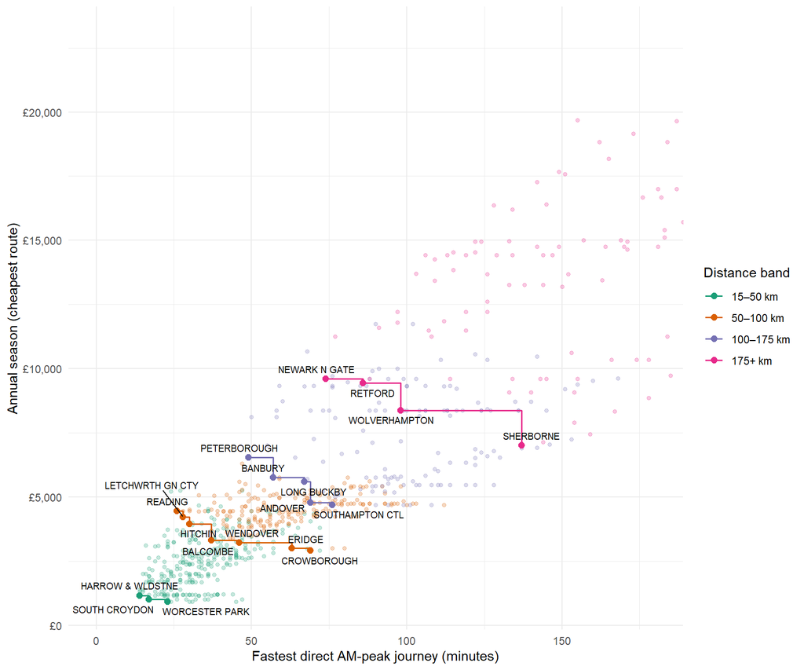

Annual season vs journey time, with the Pareto frontier drawn within each distance band. Labelled stations are undominated: in their band nothing is both faster and cheaper.

```r
tt[, band := cut(dist_km, c(15, 50, 100, 175, Inf),
                 labels = c("15–50 km", "50–100 km", "100–175 km", "175+ km"))]
fb <- tt[order(band, time_min, annual_season)]
fb[, keep := annual_season == cummin(annual_season), by = band]
frontier <- fb[keep == TRUE][, .SD[1], by = .(band, annual_season)]
ggplot(fb, aes(time_min, annual_season)) +
  geom_point(aes(colour = band), alpha = 0.25, size = 1.3) +
  geom_step(data = frontier, aes(colour = band), direction = "hv",
            linewidth = 0.7) +
  geom_point(data = frontier, aes(colour = band), size = 2.2) +
  geom_text_repel(data = frontier, aes(label = station), size = 2.7,
                  max.overlaps = 40) +
  scale_colour_brewer(palette = "Dark2", name = "Distance band") +
  scale_y_continuous(labels = label_currency(prefix = "£")) +
  coord_cartesian(xlim = c(0, 180)) +
  labs(x = "Fastest direct AM-peak journey (minutes)",
       y = "Annual season (cheapest route)") +
  theme_minimal()
```

```r
frontier[, .(Band = band, Station = station, `Mins` = time_min,
             `Annual` = comma(annual_season, prefix = "£"),
             `Km` = round(dist_km), `To` = time_terminal,
             `Cheapest via` = route_desc)] |>
  kable(caption = "Pareto-efficient stations, by distance band") |>
  kable_styling(full_width = FALSE, font_size = 12)
```

Pareto-efficient stations, by distance band

| Band | Station | Mins | Annual | Km | To | Cheapest via |
| --- | --- | --- | --- | --- | --- | --- |
| 15–50 km | HARROW & WLDSTNE | 14 | £1,168 | 17 | EUS | CLAPHAM JUNCTION |
| 15–50 km | SOUTH CROYDON | 17 | £1,012 | 16 | LBG | ANY - PERMITTED |
| 15–50 km | WORCESTER PARK | 23 | £932 | 16 | VXH | ANY - PERMITTED |
| 50–100 km | READING | 26 | £4,464 | 59 | PAD | ANY PERMITTED |
| 50–100 km | LETCHWRTH GN CTY | 28 | £4,216 | 53 | KGX | ANY - PERMITTED |
| 50–100 km | HITCHIN | 30 | £3,944 | 51 | KGX | ANY - PERMITTED |
| 50–100 km | BALCOMBE | 37 | £3,316 | 50 | LBG | THAMESLINK ONLY |
| 50–100 km | WENDOVER | 46 | £3,232 | 52 | MYB | CHALFONT & LATMR |
| 50–100 km | ERIDGE | 63 | £3,000 | 52 | LBG | ANY PERMITTED |
| 50–100 km | CROWBOROUGH | 69 | £2,924 | 56 | LBG | NOT UNDERGROUND |
| 100–175 km | PETERBOROUGH | 49 | £6,540 | 119 | KGX | GTNRTHRN&THMLINK |
| 100–175 km | BANBURY | 57 | £5,764 | 103 | MYB | ANY PERMITTED |
| 100–175 km | LONG BUCKBY | 67 | £5,604 | 110 | EUS | ANY PERMITTED |
| 100–175 km | ANDOVER | 69 | £4,784 | 101 | WAT | ANY PERMITTED |
| 100–175 km | SOUTHAMPTON CTL | 76 | £4,700 | 112 | WAT | THREE BRIDGES |
| 175+ km | NEWARK N GATE | 74 | £9,608 | 181 | KGX | EMIDSTRAINS.ONLY |
| 175+ km | RETFORD | 86 | £9,448 | 209 | KGX | HULL TRAINS ONLY |
| 175+ km | WOLVERHAMPTON | 98 | £8,380 | 182 | EUS | WMR & LNR ONLY |
| 175+ km | SHERBORNE | 137 | £7,016 | 178 | WAT | ANY PERMITTED |

Annual season vs journey time, with the Pareto frontier drawn within each distance band. Labelled stations are undominated: in their band nothing is both faster and cheaper.

### The best stations within a season-ticket budget

The frontier answers “what’s efficient overall”; a house-hunter usually asks the budget-constrained version: *given what I can spend on the season ticket, where do I get the fastest train?* First the leaderboards by price band, then the continuous version: how the fastest attainable commute falls as the budget rises, with the stations that set each new record.

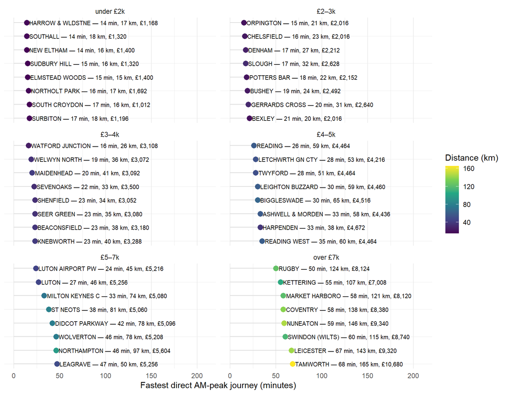

The fastest stations within each annual season price band. Colour = distance: pale, far-out stations high in a cheap band are the bargains.

```r
tt[, price_band := cut(annual_season, c(0, 2000, 3000, 4000, 5000, 7000, Inf),
                       labels = c("under £2k", "£2–3k", "£3–4k",
                                  "£4–5k", "£5–7k", "over £7k"))]
lead <- tt[order(time_min), .SD[1:8], by = price_band][!is.na(station)]
lead[, rank := seq_len(.N), by = price_band]
ggplot(lead, aes(time_min, 9 - rank)) +
  geom_segment(aes(xend = 0, yend = 9 - rank), colour = "grey85") +
  geom_point(aes(colour = dist_km), size = 3) +
  geom_text(aes(label = sprintf("%s — %d min, %.0f km, £%s",
                                station, time_min, dist_km,
                                comma(annual_season))),
            hjust = 0, nudge_x = 3, size = 2.7) +
  scale_colour_viridis_c(name = "Distance (km)") +
  facet_wrap(~price_band, ncol = 2) +
  scale_x_continuous(limits = c(0, 210)) +
  labs(x = "Fastest direct AM-peak journey (minutes)", y = NULL) +
  theme_minimal() +
  theme(axis.text.y = element_blank(), panel.grid.major.y = element_blank())
```

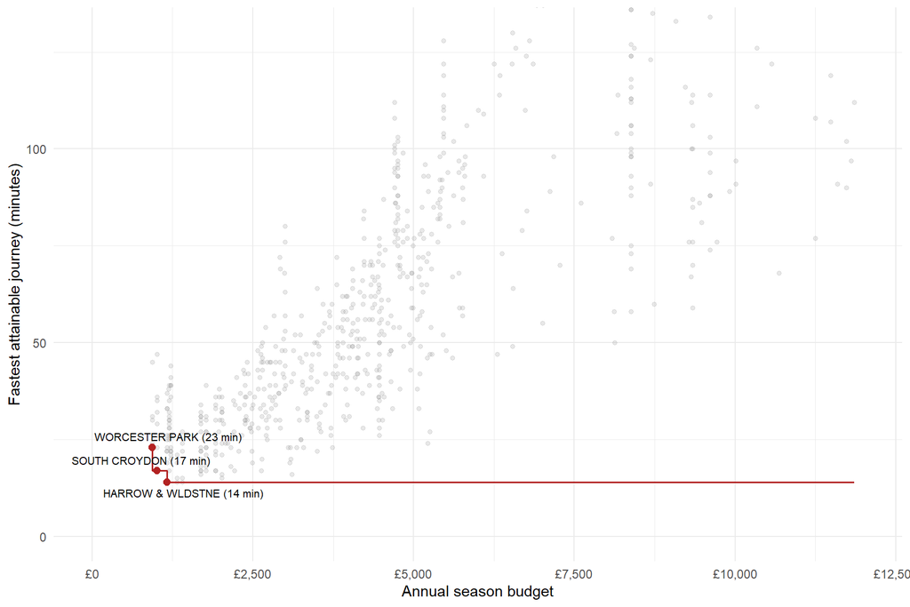

The fastest commute money can buy: minimum attainable journey time at each season-ticket budget. Labelled stations set a new speed record as the budget rises.

```r
bc <- tt[order(annual_season, time_min)]
bc[, best_time := cummin(time_min)]
records <- bc[time_min == best_time][, .SD[1], by = time_min]
ggplot(bc, aes(annual_season, time_min)) +
  geom_point(alpha = 0.2, colour = "grey55", size = 1.2) +
  geom_step(aes(y = best_time), direction = "vh", colour = "firebrick",
            linewidth = 0.7) +
  geom_point(data = records, aes(y = time_min), colour = "firebrick",
             size = 2.2) +
  geom_text_repel(data = records,
                  aes(y = time_min,
                      label = sprintf("%s (%d min)", station, time_min)),
                  size = 2.8, max.overlaps = 30) +
  scale_x_continuous(labels = label_currency(prefix = "£"),
                     limits = c(0, 12000)) +
  coord_cartesian(ylim = c(0, 130)) +
  labs(x = "Annual season budget", y = "Fastest attainable journey (minutes)") +
  theme_minimal()
```

### Price or speed? Shifting the balance

Whether a cheap-but-slow or fast-but-dear station “wins” depends on how much an hour on the train is worth to you. Re-ranking stations by generalised cost — fare plus 230 days of round-trip time valued at £λ/hour — shows the balance tipping as λ rises from zero (price is everything) to £50/hour (time is precious). Note this comparison is run for stations **at least 40 km out**: include the inner suburbs and they win at every λ, since they are both cheap and quick — the reason to move further out is housing, which is what the distance-banded frontier above captures. Out in the commuter belt proper, the tension is real: at λ = 0 the slow, cheap Oxted line dominates; by λ = £50 it has vanished in favour of the fast Thames Valley and East Coast corridors.

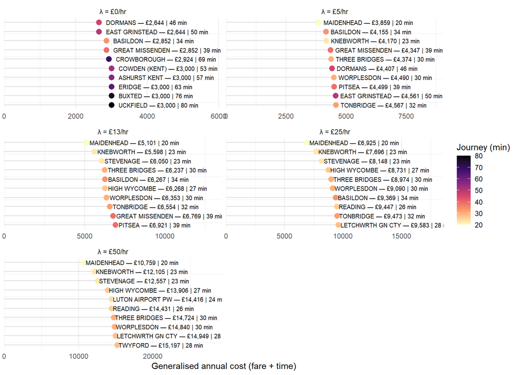

Top ten stations ≥ 40 km from London by generalised annual cost, under different values of time. £0/hr = cheapest fare wins; higher values increasingly reward speed.

```r
vots <- c(0, 5, 13.10, 25, 50)
bal <- rbindlist(lapply(vots, function(v) {
  d <- tt[dist_km >= 40 & dist_km <= 250,
          .(station, annual_season, time_min, dist_km)]
  d[, gen := annual_season + 2 * params$commuting_days * (time_min / 60) * v]
  setorder(d, gen)
  d <- d[1:10]
  d[, `:=`(rank = seq_len(.N),
           vot = sprintf("λ = £%.0f/hr", v))]
  d
}))
bal[, vot := factor(vot, levels = sprintf("λ = £%.0f/hr", vots))]
ggplot(bal, aes(gen, 11 - rank)) +
  geom_segment(aes(xend = 0, yend = 11 - rank), colour = "grey85") +
  geom_point(aes(colour = time_min), size = 3) +
  geom_text(aes(label = sprintf("%s — £%s | %d min",
                                station, comma(round(gen)), time_min)),
            hjust = 0, nudge_x = 200, size = 2.6) +
  scale_colour_viridis_c(option = "magma", direction = -1,
                         name = "Journey (min)") +
  facet_wrap(~vot, ncol = 2, scales = "free_x") +
  scale_x_continuous(expand = expansion(mult = c(0, 0.9))) +
  labs(x = "Generalised annual cost (fare + time)", y = NULL) +
  theme_minimal() +
  theme(axis.text.y = element_blank(), panel.grid.major.y = element_blank())
```

### Value for money, measured properly

With real times we can ask the sharper question: given how long the train takes **and** how far it goes, what should the season cost? Residuals from `log(annual) ~ log(time) + log(distance)` give each station’s premium or discount against the whole-network norm. (Time and distance are strongly correlated, so read the two elasticities jointly rather than separately.)

```r
m2 <- lm(log(annual_season) ~ log(time_min) + log(dist_km), data = tt)
tt[, premium2 := (exp(residuals(m2)) - 1) * 100]
cf <- coef(m2)
tbl2 <- function(dt, cap) {
  dt[, .(Station = station, `Annual` = comma(annual_season, prefix = "£"),
         `Mins` = time_min, `Km` = round(dist_km),
         `Premium vs norm` = sprintf("%+.0f%%", premium2),
         `Cheapest via` = route_desc)] |>
    kable(caption = cap) |> kable_styling(full_width = FALSE)
}
setorder(tt, premium2)
tbl2(head(tt[dist_km <= 250], 12), "Best value once time and distance are priced in")
```

Best value once time and distance are priced in

| Station | Annual | Mins | Km | Premium vs norm | Cheapest via |
| --- | --- | --- | --- | --- | --- |
| CATERHAM | £1,220 | 44 | 25 | -39% | ANY - PERMITTED |
| MALDEN MANOR | £932 | 24 | 17 | -38% | ANY - PERMITTED |
| WORCESTER PARK | £932 | 23 | 16 | -37% | ANY - PERMITTED |
| UPPER WARLINGHAM | £1,220 | 26 | 22 | -36% | ANY - PERMITTED |
| COULSDON SOUTH | £1,220 | 21 | 21 | -35% | ANY - PERMITTED |
| WHYTELEAFE SOUTH | £1,220 | 41 | 23 | -35% | ANY - PERMITTED |
| CHEAM | £1,012 | 36 | 18 | -34% | ANY - PERMITTED |
| FELTHAM | £1,196 | 26 | 21 | -34% | ANY - PERMITTED |
| SOUTH CROYDON | £1,012 | 17 | 16 | -33% | ANY - PERMITTED |
| WHYTELEAFE | £1,220 | 39 | 22 | -33% | ANY - PERMITTED |
| CHESSINGTON S | £1,196 | 31 | 21 | -33% | ANY - PERMITTED |
| KENTON | £932 | 31 | 16 | -33% | CLAPHAM JUNCTION |

```r
tbl2(tail(tt[dist_km <= 250], 12)[order(-premium2)],
     "Worst value once time and distance are priced in")
```

Worst value once time and distance are priced in

| Station | Annual | Mins | Km | Premium vs norm | Cheapest via |
| --- | --- | --- | --- | --- | --- |
| RADLETT | £3,348 | 32 | 24 | +69% | ANY - PERMITTED |
| HARPENDEN | £4,672 | 33 | 38 | +60% | ANY - PERMITTED |
| ASCOT (BERKS) | £4,464 | 50 | 40 | +52% | VIA STAINES |
| ST ALBANS CITY | £3,712 | 28 | 30 | +50% | AAA ST ALBNS ABY |
| LUTON AIRPORT PW | £5,216 | 24 | 45 | +49% | ANY - PERMITTED |
| LUTON | £5,256 | 27 | 46 | +47% | ANY - PERMITTED |
| SHOREHAM KENT | £3,256 | 57 | 29 | +47% | VIA SWANLEY |
| LEAGRAVE | £5,256 | 47 | 50 | +46% | ANY - PERMITTED |
| FARNINGHAM ROAD | £3,132 | 48 | 28 | +45% | NOT VALID ON HS1 |
| BAT & BALL | £3,500 | 64 | 33 | +44% | NOT VALID ON HS1 |
| OTFORD | £3,500 | 40 | 31 | +44% | NOT VALID ON HS1 |
| MARTINS HERON | £4,464 | 55 | 43 | +43% | VIA STAINES |

The elasticities carry a striking message: season prices scale with **distance** (a 10% longer crow-fly distance means roughly **+8.6%** on the price), while **journey time is barely priced at all** — conditional on distance its elasticity is just -0.10, indistinguishable from “speed comes free”. Fares inherit British Rail’s mileage-based structure; the *quality* of the service — an express versus a crawl — was never systematically capitalised. That is exactly why fast-corridor stations (Leicester’s 67-minute St Pancras run priced like the long journey it is by distance) can coexist with Brighton’s similar-time, much cheaper season, and why the residual spread above is where the house-hunting opportunities live.

### Case study: Brighton vs Leicester

```r
cs_nlc <- stations[name %in% c("BRIGHTON", "LEICESTER"), nlc]
cs <- sf_long[nlc %chin% cs_nlc &
              category %in% c("anytime_day_return", "offpeak_day_return",
                              "anytime_return", "offpeak_return",
                              "weekly_season", "season_basis")]
cs <- merge(cs, stations[, .(nlc, station = name)], by = "nlc")
cs_best <- cs[, .(fare = min(fare) / 100),
              by = .(station, category, route_desc, dest_name)]
dcast(cs_best, station + route_desc + dest_name ~ category,
      value.var = "fare") |>
  kable(caption = "Every priced route to London: Brighton vs Leicester (£)") |>
  kable_styling(font_size = 12)
```

Every priced route to London: Brighton vs Leicester (£)

| station | route_desc | dest_name | anytime_day_return | anytime_return | offpeak_day_return | offpeak_return | season_basis | weekly_season |
| --- | --- | --- | --- | --- | --- | --- | --- | --- |
| BRIGHTON | ANY PERMITTED | CITY THAMESLINK | 41.9 | NA | 18.2 | 33.1 | NA | 99.2 |
| BRIGHTON | ANY PERMITTED | LONDON BLKFRIARS | 41.9 | NA | 18.2 | 33.1 | NA | 99.2 |
| BRIGHTON | ANY PERMITTED | LONDON TERMINALS | 54.5 | NA | 30.9 | 36.4 | NA | 117.4 |
| BRIGHTON | ANY PERMITTED | LONDON VICTORIA | 51.9 | NA | 29.6 | 35.3 | NA | 108.3 |
| BRIGHTON | ANY PERMITTED | LONDON ZONES 1-6 | 59.2 | NA | 34.3 | NA | NA | 138.3 |
| BRIGHTON | NOT UNDERGROUND | LONDON ST PANCRS | 41.9 | NA | 18.2 | 33.1 | NA | 99.2 |
| BRIGHTON | THAMESLINK ONLY | LONDON TERMINALS | 41.9 | NA | 18.2 | 33.1 | NA | 99.2 |
| BRIGHTON | THAMESLINK ONLY | LONDON ZONES 1-6 | 49.4 | NA | 23.9 | NA | NA | 108.0 |
| LEICESTER | ANY PERMITTED | LONDON TERMINALS | NA | 162.5 | NA | 94.0 | 233 | 270.0 |
| LEICESTER | ANY PERMITTED | LONDON ZONES 1-6 | 169.5 | NA | NA | NA | NA | 289.7 |

The route-level detail shows exactly the effect you noticed: Brighton has an “any permitted” fare (usable to Victoria), a Victoria-specific fare, and a cheaper **Thameslink-only** fare into Blackfriars / City Thameslink / London Bridge — while Leicester has a single “any permitted” price to St Pancras with no cheap-route alternative, and a season basis (`PSS`) that still prices the annual at roughly **double** Brighton’s despite a similar journey time. Competition between routes, not distance, is doing the work.

## Housing: closing the triangle

Cheap seasons are worthless if the houses cost a fortune, and vice versa. To close the triangle we bring in the [house price per square metre dataset](https://data.london.gov.uk/dataset/house-price-per-square-metre-in-england-and-wales-epo9w) (every Land Registry transaction in England & Wales matched to its EPC floor area), geocoded to postcode via the ONS Postcode Directory. `R/build_station_house_prices.R` computes, for every station, the **median price per square metre of all homes sold within 2 km**, in two windows: **2016–18** (consistent with the May 2018 fares and timetable used throughout) and 2022–24. Where a rural station has fewer than 50 2016–18 sales within 2 km (Eridge, Hever, Glynde…), the circle is widened a kilometre at a time, up to 5 km, until it has enough sales for a stable median. Scottish stations drop out — the dataset covers England & Wales.

```r
hpx <- fread(file.path(dirname(feed_dir), "data", "station_house_prices.csv"))
th <- merge(tt, hpx, by = "crs")[n_1618 >= 1 & dist_km <= 250]
```

That gives **670** stations with real journey times, London fares, and nearby house sales (26 of them using a widened 3–5 km catchment; 0 still have fewer than 50 sales and are kept, flagged as small samples).

### Do house prices already price the commute?

Urban economics says they should: pay less to get into London and the saving gets capitalised into what you pay for a house near the station. Plotting the housing market against the full annual cost of commuting (fare + time) shows that trade-off operating — and, more usefully, the stations that sit *below* the curve, where the market hasn’t fully charged for the access.

```r
# trend line and residual bands: ±1σ / ±2σ around the loess fit
lo <- loess(ppm2_1618 ~ gen_cost, data = th)
th[, `:=`(fit = predict(lo, gen_cost))]
th[, resid_ppm2 := ppm2_1618 - fit]
sd_r <- sd(th$resid_ppm2)
th[, z := resid_ppm2 / sd_r]

band <- data.table(gen_cost = seq(min(th$gen_cost), max(th$gen_cost),
                                  length.out = 200))
band[, fit := predict(lo, gen_cost)]
band <- melt(band[, .(gen_cost, `trend` = fit,
                      `+1σ` = fit + sd_r, `-1σ` = fit - sd_r,
                      `+2σ` = fit + 2 * sd_r, `-2σ` = fit - 2 * sd_r)],
             id.vars = "gen_cost", variable.name = "line", value.name = "y")
band[, lt := fifelse(line == "trend", "solid",
                     fifelse(line %in% c("+1σ", "-1σ"), "dashed", "dotted"))]
band_lab <- band[, .SD[which.max(gen_cost)], by = line]

th[, txt := sprintf(paste0("%s<br>£%s/m² (median %s sales within %d km%s)<br>£%s season | ",
                           "%d min | gen. £%s pa<br>vs trend: %+.0f £/m² (%+.1fσ)"),
                    station, comma(round(ppm2_1618)), comma(n_1618), as.integer(radius_km),
                    fifelse(n_1618 < 50, " — small sample", ""),
                    comma(annual_season), time_min, comma(round(gen_cost)),
                    resid_ppm2, z)]
sdh <- highlight_key(th, ~station, group = "Housing vs commute — search stations")
gh <- ggplot(sdh, aes(gen_cost, ppm2_1618, text = txt)) +
  geom_line(data = band, aes(gen_cost, y, group = line, linetype = lt),
            colour = "grey35", linewidth = 0.5, inherit.aes = FALSE) +
  scale_linetype_identity() +
  geom_text(data = band_lab, aes(gen_cost, y, label = line),
            inherit.aes = FALSE, hjust = 0, nudge_x = 150,
            size = 3, colour = "grey30") +
  geom_point(aes(colour = time_min), alpha = 0.7, size = 1.8) +
  geom_point(data = th[abs(z) > 2], aes(gen_cost, ppm2_1618),
             inherit.aes = FALSE, shape = 1, size = 3.4,
             colour = "firebrick", stroke = 0.8) +
  scale_colour_viridis_c(name = "Journey (min)") +
  scale_x_continuous(labels = label_currency(prefix = "£"),
                     expand = expansion(mult = c(0.02, 0.08))) +
  scale_y_continuous(labels = label_currency(prefix = "£")) +
  labs(x = "Generalised annual commuting cost (fare + time)",
       y = "Median £/m², homes sold nearby (2016–18)") +
  theme_minimal()
searchable(gh)
```

[interactive chart not shown]

Median £/m² of homes sold near the station (2016–18) vs generalised annual commuting cost. Grey line = loess trend; dashed/dotted lines = ±1σ and ±2σ of the residuals around it. Ringed points sit beyond ±2σ. Searchable.

One residual standard deviation here is **£711 per m²** — on a 90 m² home, a ±1σ move is about £64k. The ringed stations beyond ±2σ are the extremes: *above* the +2σ line, housing costs far more than London access explains (places sold on schools, sea or setting rather than the commute); *below* the −2σ line, the housing is much cheaper than its commuting cost predicts.

```r
out <- th[abs(z) > 2][order(-z)]
out[, .(Station = station, `£/m²` = comma(round(ppm2_1618)),
        `Trend £/m²` = comma(round(fit)), `σ` = sprintf("%+.1f", z),
        `Season` = comma(annual_season, prefix = "£"), `Mins` = time_min)] |>
  kable(caption = "Stations more than 2σ from the housing–commute trend") |>
  kable_styling(full_width = FALSE, font_size = 12)
```

Stations more than 2σ from the housing–commute trend

| Station | £/m² | Trend £/m² | σ | Season | Mins |
| --- | --- | --- | --- | --- | --- |
| OXFORD | 6,316 | 3,674 | +3.7 | £5,096 | 57 |
| STRAWBERRY HILL | 7,244 | 5,044 | +3.1 | £1,168 | 33 |
| TEDDINGTON | 7,210 | 5,113 | +2.9 | £1,196 | 30 |
| FULWELL | 7,036 | 4,986 | +2.9 | £1,196 | 35 |
| CAMBRIDGE | 5,854 | 3,872 | +2.8 | £4,540 | 52 |
| HAMPTON WICK | 7,083 | 5,165 | +2.7 | £1,196 | 28 |
| BATH SPA | 4,503 | 2,587 | +2.7 | £9,916 | 89 |
| BROCKENHURST | 4,795 | 2,914 | +2.6 | £6,088 | 93 |
| TWICKENHAM | 7,255 | 5,408 | +2.6 | £1,168 | 19 |
| HARPENDEN | 6,026 | 4,213 | +2.5 | £4,672 | 33 |
| ST ALBANS CITY | 6,259 | 4,546 | +2.4 | £3,712 | 28 |
| KINGSTON | 6,881 | 5,242 | +2.3 | £1,196 | 25 |
| LONDON RD GUILFD | 5,710 | 4,113 | +2.2 | £3,460 | 50 |
| WINDSOR & E RIV | 5,767 | 4,190 | +2.2 | £2,976 | 51 |
| DORRIDGE | 4,158 | 2,635 | +2.1 | £8,380 | 98 |
| KINGHAM | 4,348 | 2,841 | +2.1 | £7,124 | 89 |
| COBHAM & STOKE D | 6,122 | 4,652 | +2.1 | £2,660 | 34 |
| CLAVERDON | 3,974 | 2,515 | +2.1 | £9,340 | 106 |
| GUILDFORD | 5,645 | 4,194 | +2.0 | £4,460 | 36 |
| THAMES DITTON | 6,563 | 5,113 | +2.0 | £1,196 | 30 |
| RADLETT | 5,970 | 4,537 | +2.0 | £3,348 | 32 |
| KETTERING | 1,927 | 3,354 | -2.0 | £7,008 | 55 |
| ROCHESTER | 2,794 | 4,223 | -2.0 | £4,124 | 38 |
| TILBURY TOWN | 3,156 | 4,600 | -2.0 | £2,376 | 39 |
| CHATHAM | 2,597 | 4,140 | -2.2 | £4,124 | 42 |
| GILLINGHAM KENT | 2,500 | 4,063 | -2.2 | £4,124 | 46 |
| PETERBOROUGH | 1,982 | 3,555 | -2.2 | £6,540 | 49 |
| PITSEA | 2,839 | 4,453 | -2.3 | £3,004 | 39 |
| WELLINGBOROUGH | 2,019 | 3,637 | -2.3 | £6,300 | 47 |
| NORTHAMPTON | 2,069 | 3,785 | -2.4 | £5,604 | 46 |

```r
mh <- lm(ppm2_1618 ~ I(gen_cost / 1000), data = th)
grad <- -coef(mh)[[2]]
```

The gradient is real money: across these stations, each extra **£1,000** of annual commuting cost is associated with homes about **£133 per m² cheaper** (R² = 0.54) — roughly £12k on a 90 m² house. That is the market pricing London access. The residual scatter around it is where bargains and traps live.

### The all-in cost of a London working life

To rank places on one number, price a standardised **90 m² home** at the local £/m² and add the commute as a lump sum — a perpetual annual cost capitalised at 3.5% (the Green Book discount rate; £1,000/yr forever ≈ £28,600 today). Change either assumption to taste.

```r
home_m2 <- 90; disc <- 0.035
th[, all_in := home_m2 * ppm2_1618 + gen_cost / disc]
setorder(th, all_in)
th[1:20, .(Station = station, `£/m²` = comma(round(ppm2_1618)),
           `90m² home` = comma(round(home_m2 * ppm2_1618 / 1000), prefix = "£", suffix = "k"),
           `Season` = comma(annual_season, prefix = "£"), `Mins` = time_min,
           `All-in` = comma(round(all_in / 1000), prefix = "£", suffix = "k"))] |>
  kable(caption = "Lowest all-in cost: 90 m² home + capitalised commute (2016–18 prices and fares)") |>
  kable_styling(full_width = FALSE, font_size = 12)
```

Lowest all-in cost: 90 m² home + capitalised commute (2016–18 prices and fares)

| Station | £/m² | 90m² home | Season | Mins | All-in |
| --- | --- | --- | --- | --- | --- |
| PITSEA | 2,839 | £256k | £3,004 | 39 | £453k |
| TILBURY TOWN | 3,156 | £284k | £2,376 | 39 | £464k |
| BASILDON | 3,222 | £290k | £2,852 | 34 | £469k |
| DAGENHAM DOCK | 3,978 | £358k | £1,692 | 22 | £470k |
| CHATHAM | 2,597 | £234k | £4,124 | 42 | £472k |
| OCKENDON | 3,557 | £320k | £2,376 | 30 | £474k |
| GOODMAYES | 4,184 | £377k | £1,320 | 21 | £475k |
| RAINHAM ESSEX | 3,869 | £348k | £1,916 | 25 | £475k |
| GILLINGHAM KENT | 2,500 | £225k | £4,124 | 46 | £475k |
| PURFLEET | 3,576 | £322k | £2,376 | 30 | £476k |
| LAINDON | 3,450 | £311k | £2,852 | 30 | £478k |
| ROCHESTER | 2,794 | £251k | £4,124 | 38 | £478k |
| NORTHAMPTON | 2,069 | £186k | £5,604 | 46 | £478k |
| CHADWELL HEATH | 4,047 | £364k | £1,692 | 23 | £479k |
| SEVEN KINGS | 4,302 | £387k | £1,320 | 19 | £479k |
| BELVEDERE | 3,836 | £345k | £1,772 | 31 | £485k |
| STEVENAGE | 3,485 | £314k | £3,740 | 23 | £487k |
| GRAYS | 3,509 | £316k | £2,376 | 36 | £487k |
| DARTFORD | 3,708 | £334k | £2,484 | 29 | £488k |
| ERITH | 3,765 | £339k | £2,016 | 33 | £491k |

```r
mp3 <- th[!is.na(lat)]
mp3[, ai_pct := frank(all_in) / .N * 100]
pal3 <- colorNumeric("RdYlBu", c(0, 100), reverse = TRUE)
leaflet(mp3) |>
  addProviderTiles(providers$CartoDB.Positron) |>
  addCircleMarkers(~lon, ~lat, radius = 5, stroke = FALSE, fillOpacity = 0.85,
                   fillColor = ~pal3(ai_pct),
                   label = ~sprintf("%s — all-in £%sk (£%s/m², £%s season, %d min)",
                                    station, comma(round(all_in / 1000)),
                                    comma(round(ppm2_1618)),
                                    comma(annual_season), time_min)) |>
  addLegend("bottomright", pal = pal3, values = ~ai_pct,
            title = "All-in cost percentile")
```

[interactive chart not shown]

All-in cost percentile: 90 m² home at local £/m² plus capitalised generalised commute. Blue = cheap all-in, red = dear.

### The housing–commute frontier

The all-in number bakes in assumptions; the frontier doesn’t. A station is efficient here if nowhere has **both** cheaper houses and a cheaper commute — the shortlist for anyone trading one against the other, whatever their weights.

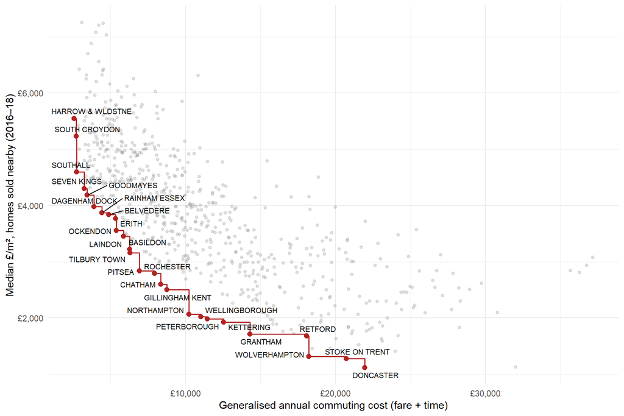

Median £/m² vs generalised annual commute. Labelled stations are Pareto-efficient: nothing is cheaper on both axes.

```r
fh <- th[order(gen_cost, ppm2_1618)]
hfront <- fh[ppm2_1618 == cummin(ppm2_1618)][, .SD[1], by = ppm2_1618]
ggplot(fh, aes(gen_cost, ppm2_1618)) +
  geom_point(alpha = 0.25, colour = "grey50", size = 1.3) +
  geom_step(data = hfront, direction = "hv", colour = "firebrick",
            linewidth = 0.7) +
  geom_point(data = hfront, colour = "firebrick", size = 2.2) +
  geom_text_repel(data = hfront, aes(label = station), size = 2.8,
                  max.overlaps = 40) +
  scale_x_continuous(labels = label_currency(prefix = "£")) +
  scale_y_continuous(labels = label_currency(prefix = "£")) +
  labs(x = "Generalised annual commuting cost (fare + time)",
       y = "Median £/m², homes sold nearby (2016–18)") +
  theme_minimal()
```

```r
hfront[, .(Station = station, `£/m²` = comma(round(ppm2_1618)),
           `Season` = comma(annual_season, prefix = "£"),
           `Mins` = time_min, `Km` = round(dist_km),
           `Gen. commute` = comma(round(gen_cost), prefix = "£"))] |>
  kable(caption = "The housing–commute efficient stations") |>
  kable_styling(full_width = FALSE, font_size = 12)
```

The housing–commute efficient stations

| Station | £/m² | Season | Mins | Km | Gen. commute |
| --- | --- | --- | --- | --- | --- |
| HARROW & WLDSTNE | 5,549 | £1,168 | 14 | 17 | £2,574 |
| SOUTH CROYDON | 5,230 | £1,012 | 17 | 16 | £2,719 |
| SOUTHALL | 4,596 | £1,320 | 14 | 18 | £2,726 |
| SEVEN KINGS | 4,302 | £1,320 | 19 | 17 | £3,228 |
| GOODMAYES | 4,184 | £1,320 | 21 | 18 | £3,429 |
| DAGENHAM DOCK | 3,978 | £1,692 | 22 | 19 | £3,902 |
| RAINHAM ESSEX | 3,869 | £1,916 | 25 | 22 | £4,427 |
| BELVEDERE | 3,836 | £1,772 | 31 | 19 | £4,885 |
| ERITH | 3,765 | £2,016 | 33 | 21 | £5,330 |
| OCKENDON | 3,557 | £2,376 | 30 | 29 | £5,389 |
| LAINDON | 3,450 | £2,852 | 30 | 39 | £5,865 |
| BASILDON | 3,222 | £2,852 | 34 | 41 | £6,267 |
| TILBURY TOWN | 3,156 | £2,376 | 39 | 34 | £6,293 |
| PITSEA | 2,839 | £3,004 | 39 | 44 | £6,921 |
| ROCHESTER | 2,794 | £4,124 | 38 | 46 | £7,940 |
| CHATHAM | 2,597 | £4,124 | 42 | 47 | £8,342 |
| GILLINGHAM KENT | 2,500 | £4,124 | 46 | 49 | £8,744 |
| NORTHAMPTON | 2,069 | £5,604 | 46 | 97 | £10,224 |
| WELLINGBOROUGH | 2,019 | £6,300 | 47 | 96 | £11,020 |
| PETERBOROUGH | 1,982 | £6,540 | 49 | 119 | £11,461 |
| KETTERING | 1,927 | £7,008 | 55 | 107 | £12,532 |
| GRANTHAM | 1,713 | £7,272 | 70 | 160 | £14,302 |
| RETFORD | 1,682 | £9,448 | 86 | 209 | £18,085 |
| WOLVERHAMPTON | 1,316 | £8,380 | 98 | 182 | £18,222 |
| STOKE ON TRENT | 1,274 | £11,592 | 91 | 218 | £20,731 |
| DONCASTER | 1,118 | £12,212 | 97 | 235 | £21,954 |

Median £/m² vs generalised annual commute. Labelled stations are Pareto-efficient: nothing is cheaper on both axes.

### Brighton vs Leicester, settled?

```r
bl <- th[station %in% c("BRIGHTON", "LEICESTER")]
gap_house <- diff(range(home_m2 * bl$ppm2_1618))
gap_gen   <- diff(range(bl$gen_cost)) / disc
```

The housing data finally adjudicates the opening puzzle. Around Brighton, 2016–18 buyers paid a median £4,917/m² against £1,893/m² around Leicester — about **£272k more for a 90 m² home**. Leicester’s dearer season plus its slightly longer journey amount to a capitalised commuting penalty of roughly **£167k**. On these assumptions the extra cost of Brighton’s housing outweighs its famously cheaper ticket: all-in, Leicester comes out ahead — the market has more than priced Brighton’s Thameslink bargain into its postcodes.

## Caveats and next steps

- **Journey times are estimated from distance** unless `data/journey_times.csv` is supplied. `R/build_journey_times.R` builds that file from a real timetable: download one of (a) **NWR Historical Timetable Data** on the [Rail Data Marketplace](https://raildata.org.uk/dataProducts) — includes the **May 2018** timetable matching this fares feed; (b) the RDG **Timetable – Full Refresh** product there (current); or (c) the free ATOC `ttis*.zip` from the [National Rail Data Portal](https://opendata.nationalrail.co.uk) — then the script converts it to GTFS with `UK2GTFS` and computes the fastest direct AM-peak journey to each London terminal.
- **Fares are May 2018.** Swap in a current `RJFAFxxx` feed from the Marketplace “Fares” product; nothing else needs changing.
- Advance (train-specific) fares, Oyster/contactless PAYG within the zones, and railcard discounts are out of scope — this is walk-up, adult, standard-class pricing.
- Only fares priced *towards* London (or explicitly reversible) are used — contra-peak fares out of London are often cheaper and would bias the panel.
- Zone-priced stations (the Thameslink belt) are represented by their **Travelcard** fares — the only walk-up products to central London the feed holds for them. A Travelcard includes zonal Tube/bus travel, so these stations’ fares buy a little more than the terminal-only fares used elsewhere; their “value” is if anything slightly understated. Stations wholly *inside* the TfL zones (e.g. Mill Hill Broadway, Elstree & Borehamwood) have no station-specific National Rail fare to London at all — their price is the TfL zonal product — and so drop out of the panel.
- Restriction codes (`.RST`) — e.g. exactly *which* trains count as off-peak — are carried through but not decoded; two “off-peak” fares can have different fine print.
- The same pipeline generalises to any other city: replace the fare-group NLC (`1072`) with e.g. Birmingham stations’ group and re-run.
- Housing figures are **medians of what actually sold within 2 km** (3–5 km for thin rural stations) in 2016–18 — they reflect the local dwelling mix (a flat-heavy town reads cheaper per m² than a detached suburb at the same underlying land value). The 90 m² home and 3.5% capitalisation rate in the all-in ranking are assumptions to vary, and England & Wales coverage only. The 2022–24 window (`ppm2_2224` in `data/station_house_prices.csv`) is there for a present-day re-run alongside a current fares feed; the UK HPI local-authority series could put both windows on a common price basis.